# Introducción al lenguaje R

ggplot2: gramática de un gráfico

## 1. Las librerías y la base de datos

Primero invocamos a `tidyverse` para utilizar el método `read_csv` del paquete `readr`. Luego, volvemos a cargar nuestro set de datos de propiedades inmobiliarias.

```r
library(tidyverse)
path <- "https://storage.googleapis.com/python_mdg/carto_cursos/ar_properties.csv.gz"

df <- read_csv(path,
               col_names=TRUE)
```

Hacemos un poco de limpieza y nos quedamos con una jurisdicción y una tipología. Digamos que vamos a trabajar con **departamentos en alquiler en la ciudad de Buenos Aires**.

```r
caba <- df %>% filter(l2 == "Capital Federal", operation_type=="Alquiler", currency=="ARS",
                      property_type=="Departamento", surface_covered > 0, surface_covered < 500, price > 0)

#Borro df y libero memoria
rm(df)
gc()
```

```
##           used (Mb) gc trigger  (Mb)  max used  (Mb)
## Ncells 1268763 67.8    4876552 260.5   4052376 216.5
## Vcells 7479203 57.1  103600575 790.5 129492297 988.0
```

## 2. Gramática de un gráfico con `ggplot2`

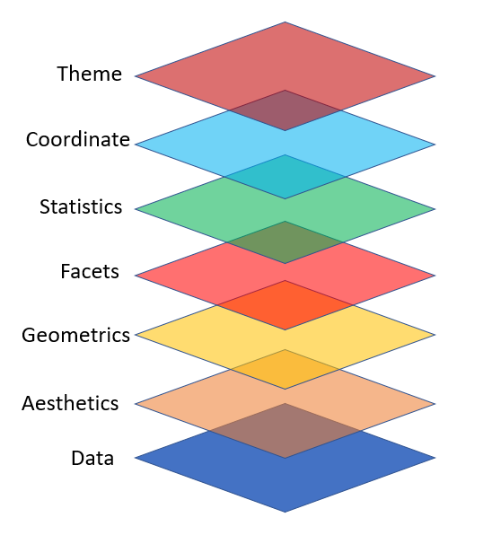

El primer componente de un gráfico es su área. Esta la podemos definir con el método `ggplot()`, especificando los parámetros `data` y `mapping` de la siguiente manera.

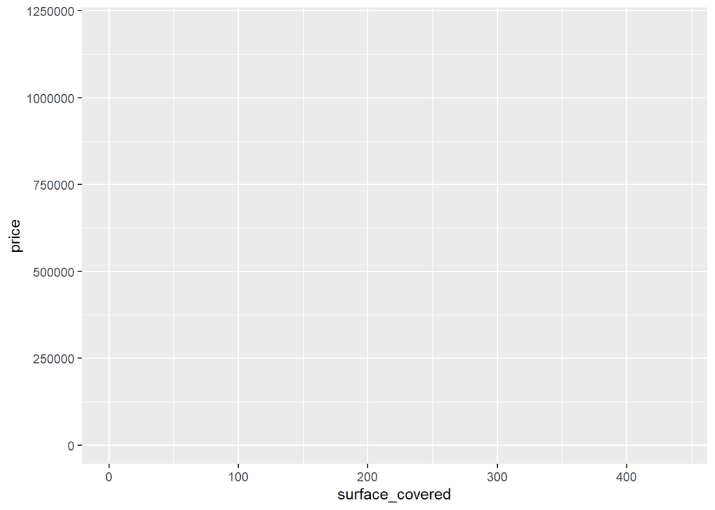

```r
# iniciamos el área de un gráfico
ggplot(data=caba, mapping = aes(x=surface_covered,y=price))
```

Pero para poder representar nuestra información en este área necesitamos una capa adicional. La geometría es la que ofrece distintas alternativas de representación visual en función de la naturaleza de nuestros datos. Los nombres de las funciones de geometría siguen el patrón: geom_X donde X es el nombre de la geometría. Algunos ejemplos incluyen `geom_point`, `geom_line`,`geom_bar` y `geom_histogram`.

## 3. Geometrías

### Gráficos de dispersión

Supongamos que queremos ver cuánto crece el precio de un departamento en alquiler en función de su tamaño. Para eso vamos a necesitar hacer un gráfico de dispersión que nos permita inspeccionar si existe algún tipo de relación. Veamos el método `geom_point()` para ello.

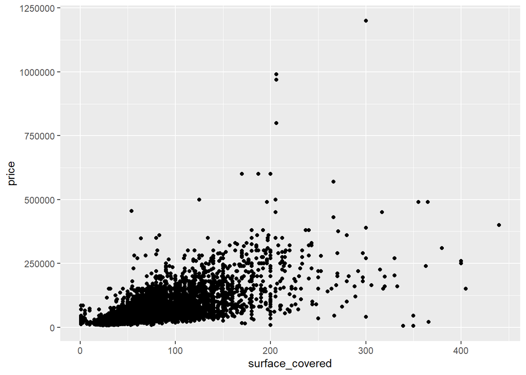

```r
# agregamos una geometría
ggplot(data = caba, mapping = aes(x = surface_covered, y = price))  +
  geom_point()
```

### Series de tiempo

Otra cuestión que nos podría interesar es de qué manera evolucionó el precio de un departamento en alquiler. Hagamos primero un par de transformaciones. Si queremos utilizar la función `geom_line` para representar una serie de valores a lo largo del tiempo, lo primero que tenemos que tener en cuenta es que nuestro eje x debe estar representado por un objeto de clase `Date`.

```r
# Agregamos algunas columnas y filtramos nuestros datos
caba_ <- caba %>%
  mutate(yearpub=substr(start_date, 1, 4),
         monthpub=months(start_date)) %>%
  filter(price < 350000)

# Creamos un df de etiquetas
months_df <- data.frame(monthpub=c("enero","febrero","marzo","abril", "mayo","junio","julio",
                       "agosto","septiembre","octubre","noviembre","diciembre"),
                        monthcod=c("01-01","02-01","03-01","04-01","05-01",
                                   "06-01","07-01","08-01","09-01","10-01","11-01","12-01"))

# Terminamos de emprolijar el set de datos de alquileres en buenos aires
caba_time <- left_join(caba_, months_df, by="monthpub") %>%
  unite("periodPubChr", c("yearpub", "monthcod"), sep="-", remove = FALSE) %>%
  mutate(periodPub=as.Date(periodPubChr,format='%Y-%m-%d'))
```

Esta es la serie de valores que vamos a querer representar …

```r
# vemos el dataset
caba_time %>% select("periodPub","price") %>% head()
```

```
## # A tibble: 6 × 2
##   periodPub  price
##   <date>     <dbl>
## 1 2020-08-01 20000
## 2 2020-08-01 16000
## 3 2020-08-01 19000
## 4 2020-08-01 26000
## 5 2020-08-01 16500
## 6 2020-08-01 32000
```

Con esta serie, vamos a generar una sumarización que nos permita calcular el precio promedio por período. La tabla `serie_precios` es la que vamos a utilizar para graficar nuestros valores de precio.

```r
# Hacemos una sumarización
serie_precios <- caba_time %>%
  group_by(periodPub) %>%
  summarise(avg_price=mean(price))
```

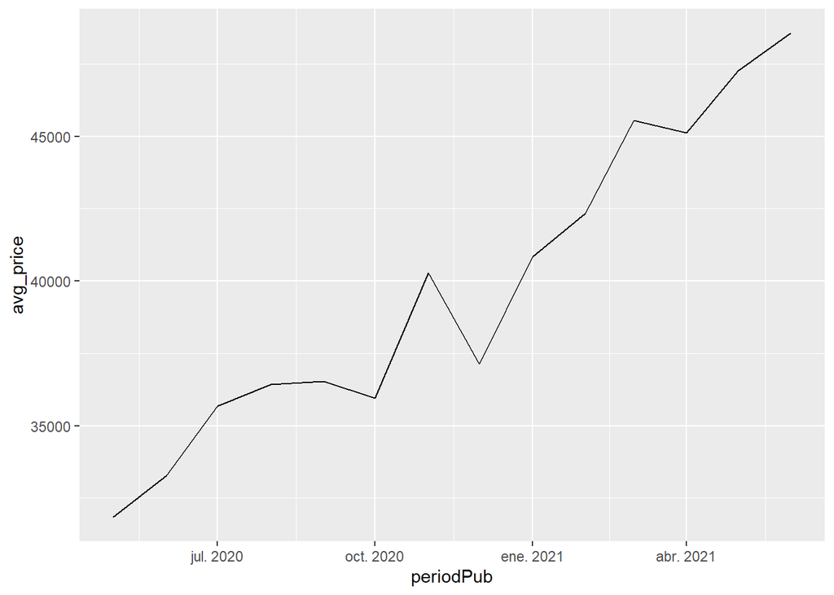

```r
# Y visualizamos un line chart
ggplot(data = serie_precios,
       mapping = aes(x = periodPub, y = avg_price)) +
  geom_line()
```

### Distribuciones

Como toda variable continua, el precio puede ser modelado a partir de una distribución. Veamos qué alternativas tenemos para representar la distribución de precios de la variable departamentos en alquiler.

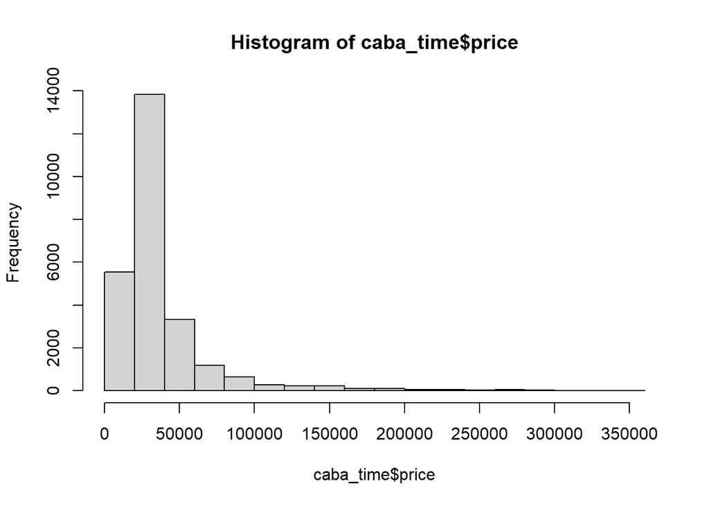

```r
# también podemos utilizar r base
hist(caba_time$price)
```

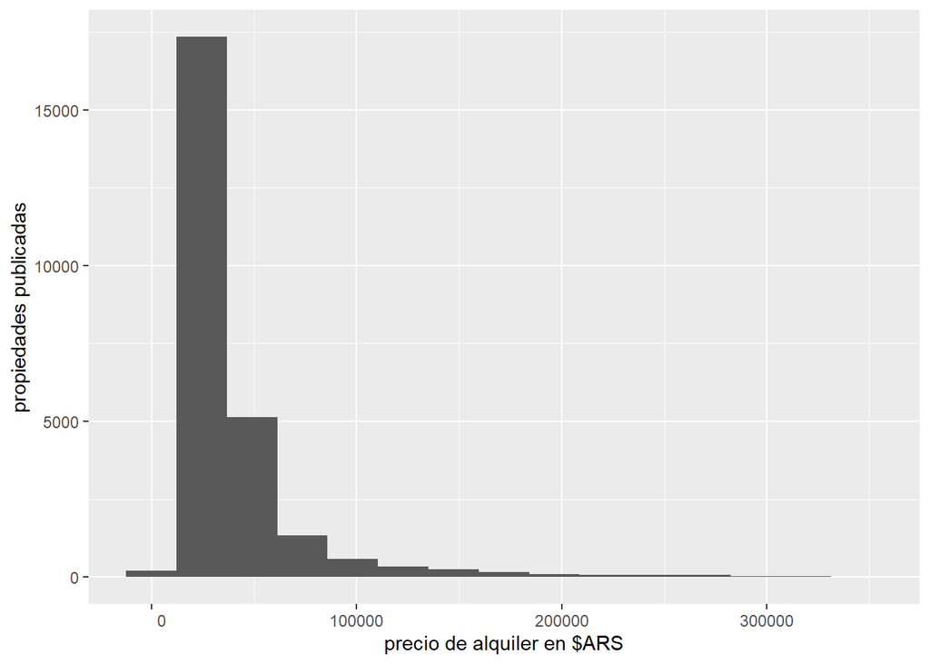

```r
# con ggplot
ggplot(caba_time, aes(price)) +
  geom_histogram(bins=15) +
  xlab("precio de alquiler en $ARS") +
  ylab("propiedades publicadas") +
  scale_x_continuous(labels = function(x) format(x, scientific = FALSE))
```

Podemos ver que la distribución de precios está un tanto sesgada hacia su derecha. Es decir, algunos casos extremos generados por valores de precio exageradamente altos.

Los gráficos de caja son una buena opción para trabajar con distribuciones. A continuación, vemos el precio del alquiler para cada período de nuestra serie. Esta visualización se genera con `geom_boxplot()` y nos informa la mediana de la distribución al centro de la caja. Con el argumento `outlier.shape` podemos excluir los valores extremos.

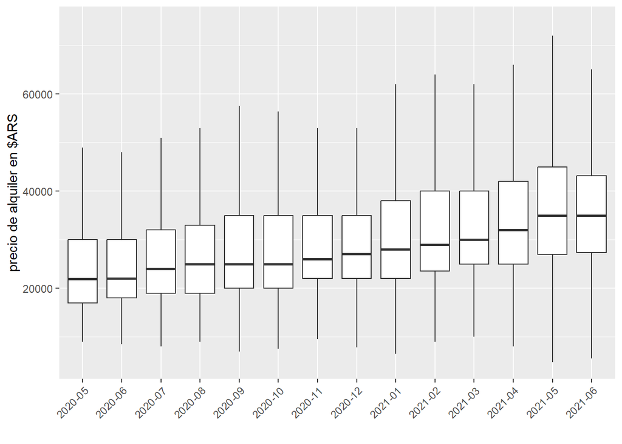

```r
# reducimos el nivel de dispersion de nuestra variable "precio"
caba_time_ <- caba_time %>% filter(price < 75000)

ggplot(caba_time_, aes(x = periodPubChr, y=price)) +
  geom_boxplot(outlier.shape = NA) +
  scale_x_discrete(labels=sapply(caba_time_$periodPubChr, substr, start=1, stop=7),
                   guide = guide_axis(angle = 45)) +
  scale_y_continuous(labels = function(x) format(x, scientific = FALSE)) +
  ylab("precio de alquiler en $ARS") + xlab("")
```

### Gráficos de barras

Ahora bien, ¿contamos con la misma cantidad de información para cada uno de los períodos analizados? Veamos cuál es el volumen de avisos con el método `geom_bar()`.

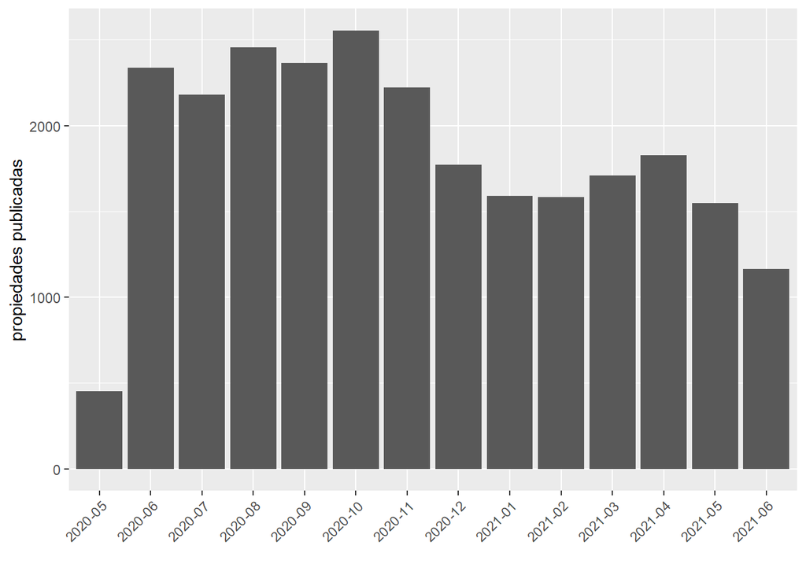

```r
ggplot(caba_time, aes(substr(periodPubChr, 1, 7))) +
  geom_bar() +
  scale_x_discrete(guide = guide_axis(angle = 45)) +
  xlab("") +
  ylab("propiedades publicadas")
```

Otro de los usos que podemos darle a esta geometría es el de calcular algún estadístico resumen. Por ejemplo, el precio promedio por barrio.

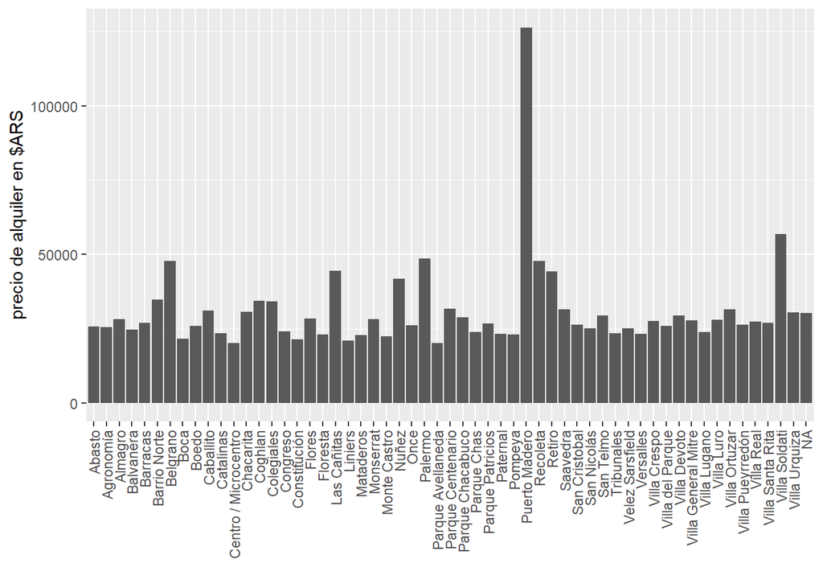

```r
ggplot(caba_time, aes(x=l3, y=price)) +
  geom_bar(stat='summary', fun='mean') +
  scale_x_discrete(guide = guide_axis(angle = 90)) +
  xlab("") + ylab("precio de alquiler en $ARS") +
  scale_y_continuous(labels = function(x) format(x, scientific = FALSE))
```

Alternativamente, podemos armar una tabla con el estadístico y utilizar `geom_col()`. Con tidyverse todo esto se puede hacer concatenando funciones.

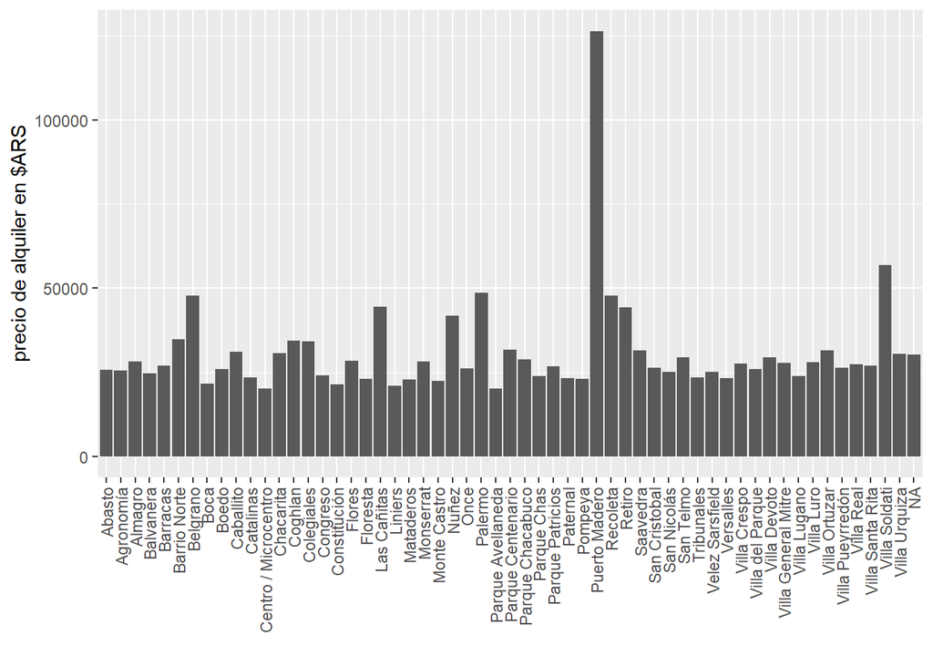

```r
caba_time %>%
  group_by(l3) %>%
  summarise(price = mean(price)) %>%
  ggplot(aes(x=l3, y=price)) +
  geom_col() +
  scale_x_discrete(guide = guide_axis(angle = 90)) +
  xlab("") + ylab("precio de alquiler en $ARS") +
  scale_y_continuous(labels = function(x) format(x, scientific = FALSE))
```

Un recurso muy útil para geometrías de puntos y líneas es `geom_smooth()`.

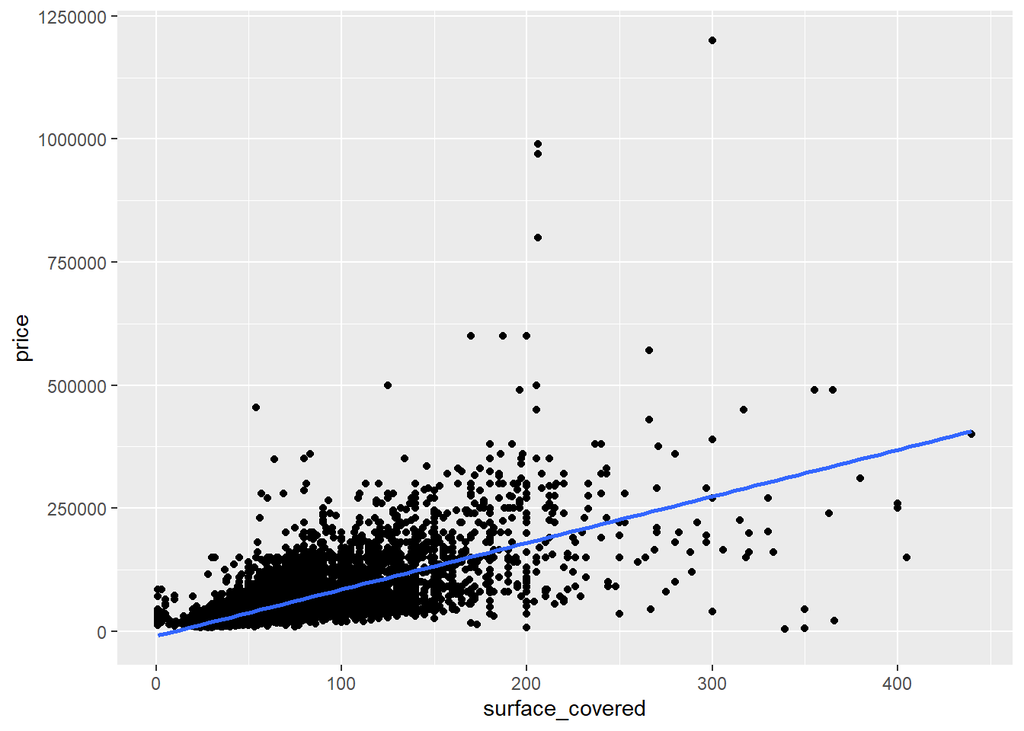

```r
# este nos permite visualizar la recta de mejor ajuste en un gráfico de dispersión
ggplot(data = caba, mapping = aes(x = surface_covered, y = price))  +
  geom_point() +
  geom_smooth(method = "lm", se = FALSE)
```

## 4. Cambiar la apariencia de una geometría

En el transcurso de los ejemplos anteriores hemos ido adelantando una serie de transformación sobre los componentes principales de un gráfico: sus ejes.

Repasemos algunas:

- `xlab`: modifica las etiquetas del eje x
- `ylab`: modifica las etiquetas del eje y Otra opción es usar labs(x=“..”, y=“..”)
- `scale_x_continuous` : nos permite transformar la escala de valores de una variable continua en el eje x
- `scale_y_continuous`: nos permite transformar la escala de valores de una variable continua en el eje y
- `scale_x_discrete` : nos permite definir el aspecto de los valores discretos de las etiquetas del eje x
- `scale_y_discrete` : nos permite definir el aspecto de los valores discretos de las etiquetas del eje y
- `scale_x_date` : nos permite definir el aspecto de los valores de tipo fecha

Con estas funciones cambiamos la posición de las etiquetas, el tipo de notación y los títulos de los ejes. Veamos qué otro tipo de transformaciones podemos hacer.

### Colores

El argumento `color` se mapea dentro de la función `aes`. Este modifica el color de líneas y puntos y se puede aplicar tanto dentro de `mapping` como dentro de `geom_x` (siempre dentro de `aes()`).

Vamos a crear dos grupos de departamentos, los de un baño solamente y los de más de un baño. Con esta nueva variable, vamos a ver en qué cuadrante se ubica cada tipo de propiedad en un gráfico de dispersión que considere precio y superficie.

```r
# creamos una función para re etiquetar
label_bath <- function(x){
  if (x <= 1){
    return("Un baño")
  } else {
    return("Dos baños o más")
    }
}

# agregamos la nueva columna
caba_time <- caba_time %>%
  mutate(bathrooms_chr = sapply(replace_na(caba_time$bathrooms,1), label_bath))

unique(caba_time$bathrooms_chr)
```

```
## [1] "Un baño"         "Dos baños o más"
```

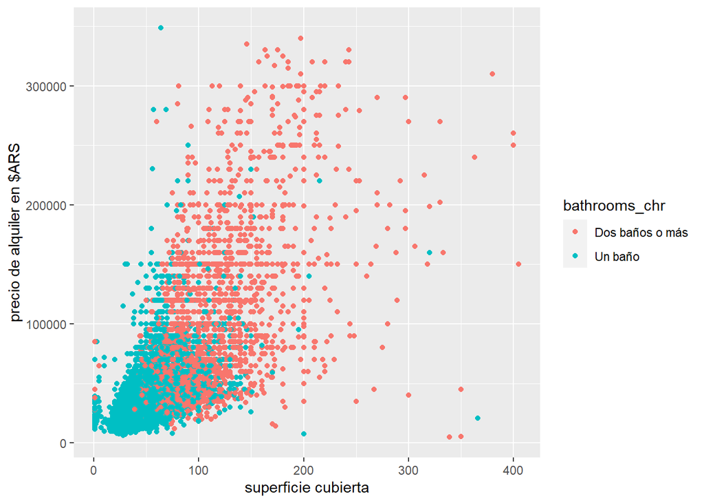

```r
ggplot(data = caba_time, mapping = aes(x = surface_covered, y = price, color=bathrooms_chr))  +
  geom_point() +
  ylab("precio de alquiler en $ARS") + xlab("superficie cubierta") +
  scale_y_continuous(labels = function(x) format(x, scientific = FALSE))
```

Podemos aplicarlo dentro del geom_, al igual que el resto de las variables de mapping y la data.

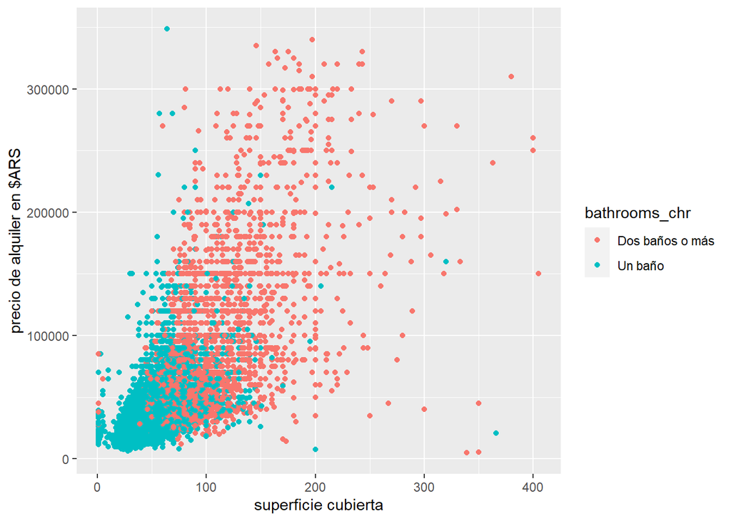

```r
#Lo dentro del geom_
ggplot() +
  geom_point(data = caba_time, mapping = aes(x = surface_covered, y = price,
             color=bathrooms_chr)) +
  ylab("precio de alquiler en $ARS") + xlab("superficie cubierta") +
  scale_y_continuous(labels = function(x) format(x, scientific = FALSE))
```

Los argumentos que queramos fijar para todo el geom_ deben ir por fuera del aes(). Por ejemplo, podemos colorear todos los puntos del mismo color.

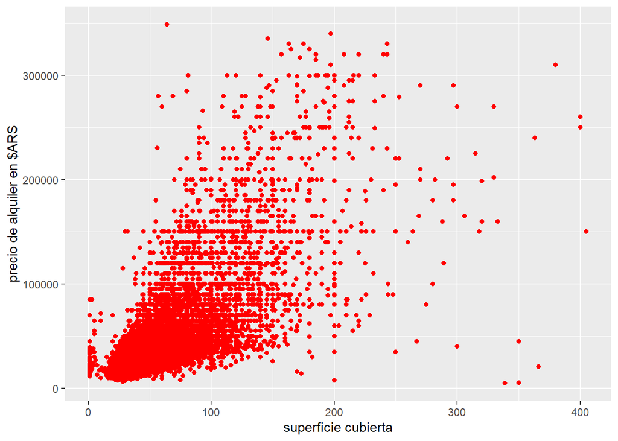

```r
ggplot() +
  geom_point(data = caba_time,
             mapping = aes(x = surface_covered, y = price),color = "red") +
  ylab("precio de alquiler en $ARS") + xlab("superficie cubierta") +
  scale_y_continuous(labels = function(x) format(x, scientific = FALSE))
```

### Relleno

Con `fill` podemos cambiar el color interno de un elemento, por ejemplo de un conjunto de barras

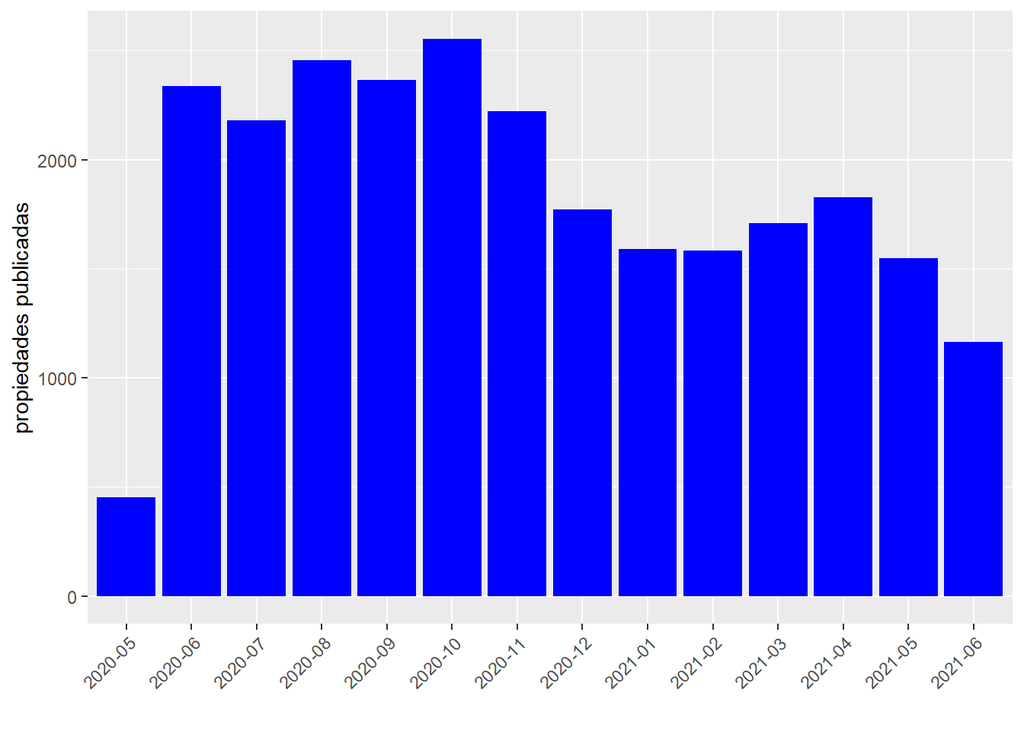

```r
ggplot(caba_time, aes(substr(periodPubChr, 1, 7))) +
  geom_bar(fill = "blue") +
  scale_x_discrete(guide = guide_axis(angle = 45)) +
  xlab("") + ylab("propiedades publicadas")
```

### Combinar estilos y geometrías

Otro recurso estético es combinar distintos tipos de geometrías. Por ejemplo, líneas y puntos. Esto también abre la posibilidad a combinar distintos estilos.

Con `linetype` podemos cambiar el tipo de línea en `geom_line`. Y con `shape` y `size` la forma y el tamaño de la geometría en un `geom_point`. También se puede utilizar el argumento `alpha` para regular la transparencia de una figura (de 0 a 1).

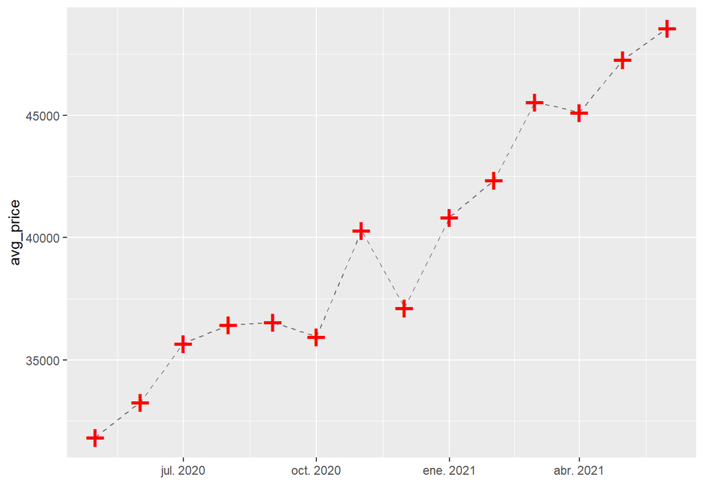

```r
ggplot(data = serie_precios,
       mapping = aes(x = periodPub, y = avg_price)) +
  geom_line(linetype="dashed", alpha=0.5) +
  geom_point(color="red", shape="+", size=9) + xlab("")
```

### Ajustar tema

También podemos utilizar la función `theme()` y sus variantes `theme_x()` para hacer retoques generales en el gráfico.

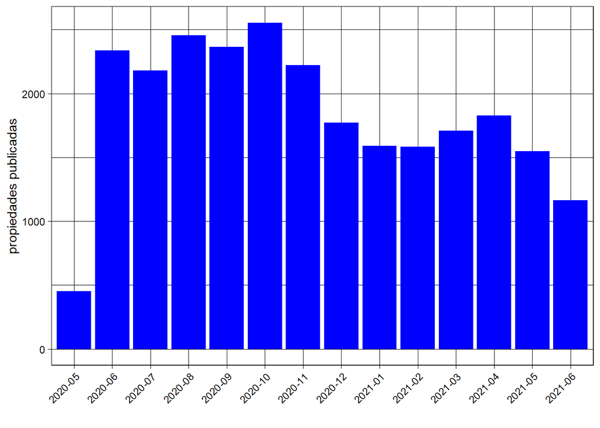

```r
###Temas predefinidos
ggplot(caba_time, aes(substr(periodPubChr, 1, 7))) +
  geom_bar(fill = "blue") +
  scale_x_discrete(guide = guide_axis(angle = 45)) +
  xlab("") +
  ylab("propiedades publicadas") +
  theme_linedraw()
```

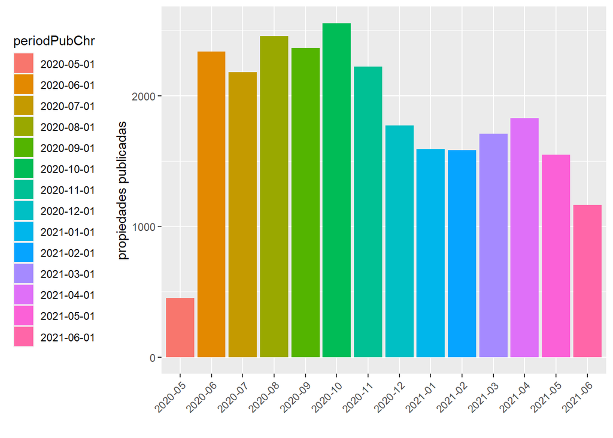

```r
###Leyenda
ggplot(caba_time, aes(substr(periodPubChr, 1, 7))) +
  geom_bar(aes(fill = periodPubChr)) +
  scale_x_discrete(guide = guide_axis(angle = 45)) +
  xlab("") +
  ylab("propiedades publicadas") +
  theme(legend.position = "left")
```